# signeR

#### *Rafael Rosales, Rodrigo Drummond, Renan Valieris, Israel Tojal da Silva*

## 1: Introduction

Motivation: Cancer is an evolutionary process driven by continuous acquisition of genetic variations in individual cells. The diversity and complexity of somatic mutational processes is a conspicuous feature orchestrated by DNA damage agents and repair processes, including exogenous or endogenous mutagen exposures, defects in DNA mismatch repair and enzymatic modification of DNA. The identification of the underlying mutational processes is central to understanding of cancer origin and evolution.

The **signeR** package focus on the characterization and analysis of mutational processes. Its functionalities can be divided in three steps. Firstly, it provides tools to process VCF files and generate matrices of SNV mutation counts and mutational opportunities, both divided according to a 3bp context (mutation site and its neighboring bases). Secondly, the main part of the package takes those matrices as input and applies a Bayesian approach to estimate the number of underlying signatures and their mutational profiles. Thirdly, the package provides tools to correlate the activities of those signatures with other relevant information, e.g. clinical data, in order to infer conclusions about the analyzed genome samples, which can be useful for clinical applications.

## 2: Installation

Before installing, please make sure your R version is **3.2.2** or superior.

**signeR** will soon be available on [Bioconductor](http://bioconductor.org/) but in the meantime it must be installed manually. A [installer script](https://github.com/rvalieris/signeR/blob/gh-pages/install_signeR.R) is available to make the installation process easier:

```r
# this will install all dependencies and signeR
source("http://rvalieris.github.io/signeR/install_signeR.R")
```

Once installed the library can be loaded:

```r
library(signeR)
```

OS X users might experience compilation errors due to missing gfortran libraries. Please read the troubleshooting section for a solution.

## 3: Preparing the input

**signeR** takes as input a count matrix of samples x features. Each feature is usually a SNV mutation within a 3bp context (96 features). Optionally, an opportunity matrix can also be provided containing the count frequency of the features in the whole analyzed region for each sample. Although not required, this argument is highly recommended because it allows **signeR** to normalize the features frequency over the analyzed region.

Input matrices can be read both from a VCF or a tab-delimited files, as described next.

### 3.1: Input from VCF

The [VCF](http://www.1000genomes.org/wiki/Analysis/vcf4.0) file format is the most common format for storing genetic variations, the **signeR** package includes a utility function for generating a count matrix from the VCF:

```r
library(VariantAnnotation)

# BSgenome, equivalent to the one used on the variant call
library(BSgenome.Hsapiens.UCSC.hg19)

vcfobj <- readVcf("/path/to/a/file.vcf", "hg19")
mut <- genCountMatrixFromVcf(BSgenome.Hsapiens.UCSC.hg19, vcfobj)
```

This function will generate a matrix of mutation counts for each sample in the provided VCF. The opportunity matrix can also be generated from the reference genome (hg19 in the following case):

```r
library(rtracklayer)

target_regions <- import(con="/path/to/a/target.bed", format="bed")
opp <- genOpportunityFromGenome(BSgenome.Hsapiens.UCSC.hg19,
    target_regions, nsamples=nrow(mut))
```

Where `target.bed` is a [bed file](https://genome.ucsc.edu/FAQ/FAQformat.html#format1) containing the genomic regions analyzed by the variant caller.

### 3.2: Input from tab-delimited file

By convention, the input file should be tab-delimited with sample names as row names and features as column names. Features should be refered in the format "base change:triplet", e.g. "C>A:TCG", as can be seen in the example below. Similarly, the opportunity matrix can be provided in a tab-delimited file with the same structure as the mutation counts file. An example of the required matrix format can be seen [here](https://github.com/rvalieris/signeR/blob/master/inst/extdata/21_breast_cancers.mutations.txt).

This tutorial uses as input the 21 breast cancer dataset from [Nik-Zainal et al 2012](http://dx.doi.org/10.1016/j.cell.2012.04.023) paper. For the sake of convenience this dataset is included with the package and can be accessed by using the `system.file` function:

```r
mut <- read.table(system.file("extdata","21_breast_cancers.mutations.txt",
    package="signeR"), header=TRUE, check.names=FALSE)
opp <- read.table(system.file("extdata","21_breast_cancers.opportunity.txt",
    package="signeR"))
```

## 4: Generating the signatures

**signeR** takes a count matrix as its only required parameter, but the user can provide an opportunity matrix as well. The algorithm allows the assessment of the number of signatures by three options, as following.

1. signeR detects the number of signatures at run time:

   ```r
   signatures <- signeR(M=mut, Opport=opp)
   ```

2. The user can give a interval of the possible numbers of signatures as the parameter nlim. **signeR** will calculate the optimal number of signatures within this range, for example:

   ```r
   signatures <- signeR(M=mut, Opport=opp, nlim=c(2,11))
   ```

3. Finally, **signeR** can also be run by passing the number of signatures as the parameter nsig. In this setting, the algorithm is faster. For example, the following command will make **signeR** consider only the rank N=5 to estimate the signatures and their exposures:

   ```r
   signatures <- signeR(M=mut, Opport=opp, nsig=5)
   ```

The parameters `testing_burn` and `testing_eval` control the number of iterations used to estimate the number of signatures (default value is 1000 for both parameters). Whenever **signeR** is left to decide which number of signatures is optimal, it will search for the rank Nsig that maximizes the median BIC. After the processing is done, this information can be plotted by the following command:

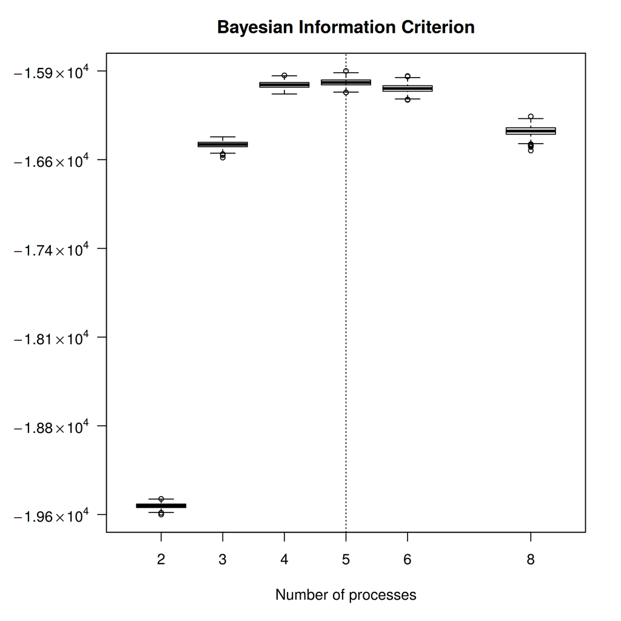

```r
BICboxplot(signatures)
```

Boxplot of BIC values, showing that the optimal number of signatures for this dataset is 5.

## 5: Results and further analyses

### 5.1: Plot the paths

Plots of signatures and exposures individual entries along successive iterations of the Gibbs sampler. Useful to check if entries have leveled off, what reflects the sampler convergence.

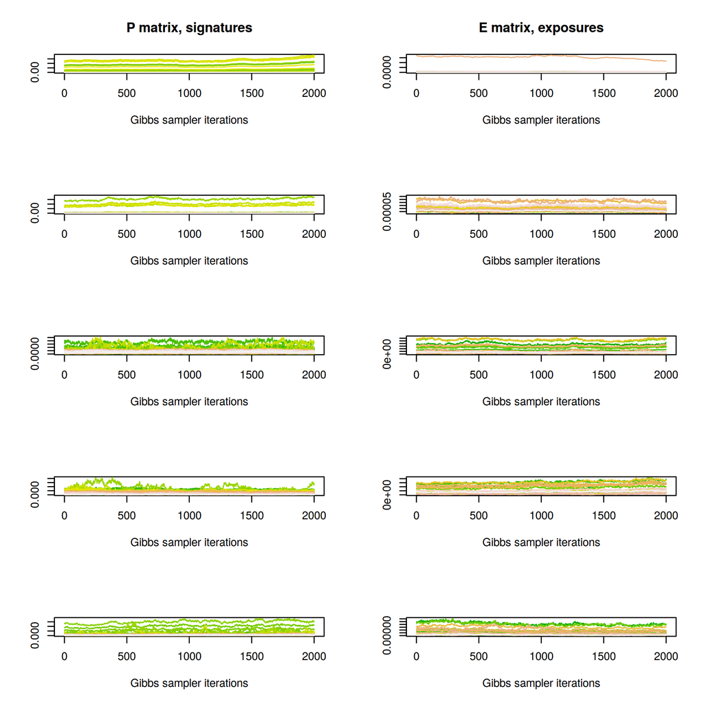

```r
Paths(signatures$SignExposures)
```

Each plot shows the entries and exposures of one signature along sampler iterations.

### 5.2: Plot the signatures

Once the processing is done, estimated signatures can be visualized by issuing the following command:

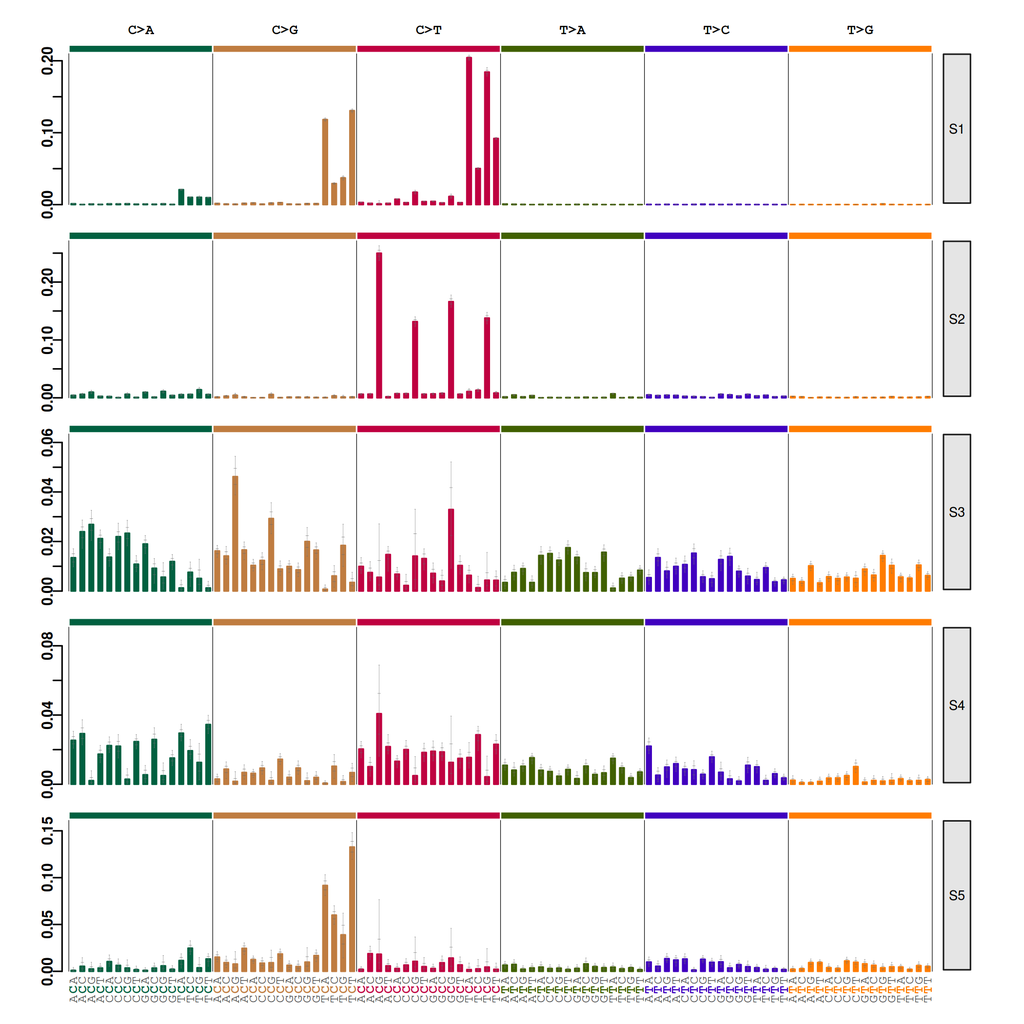

```r
SignPlot(signatures$SignExposures)
```

Signatures barplot with error bars reflecting the sample percentiles 0.05, 0.25, 0.75, and 0.95 for each entry.

### 5.3: Plot the exposures

The levels of exposure to each signature in all genome samples can also be plotted:

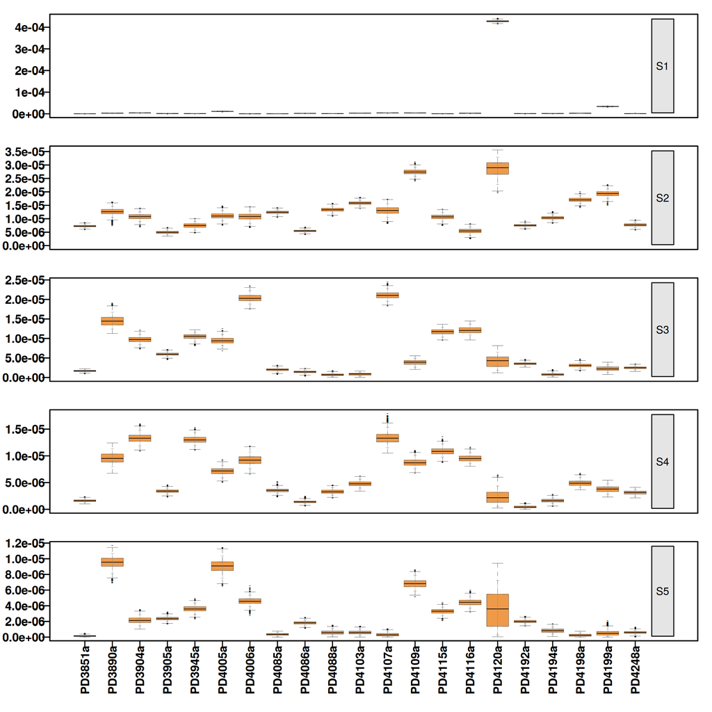

```r
ExposureBoxplot(signatures$SignExposures)
```

### 5.4: Signature heatmap

Estimated signatures can also be visualized in a heatmap, generated by the following command:

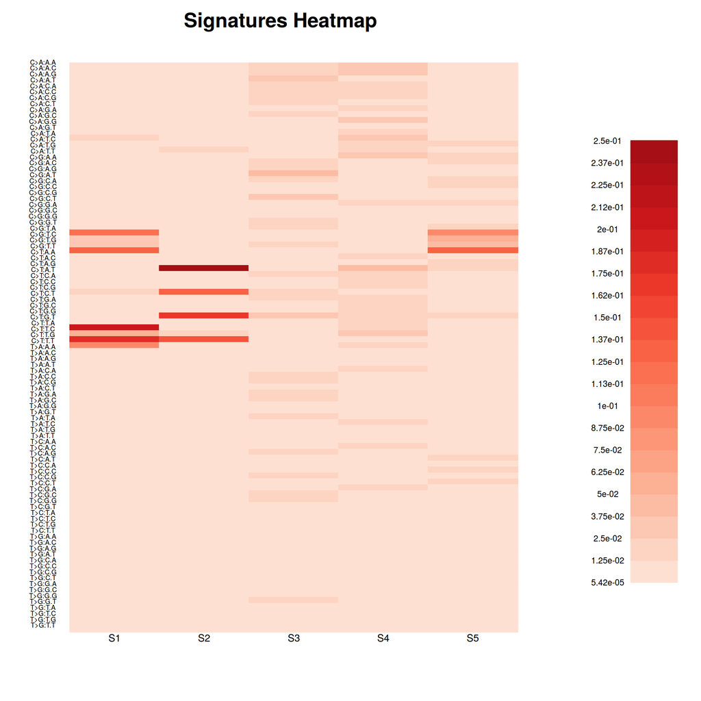

```r
SignHeat(signatures$SignExposures)
```

Heat map showing the entries of each signature.

### 5.5: Exposure heatmap

The levels of exposure to each signature can also be plotted in a heatmap:

```r
ExposureHeat(signatures$SignExposures)
```

[output not shown]

[output not shown]

### 5.6: Differential Exposure Analysis

**signeR** can highlight signatures that are differentially active among previously defined groups of samples. To perform this task **signeR** needs a vector of group labels. In this example the samples were divided according to germline mutations at BRCA genes: groups `wt`, `BRCA1+` and `BRCA2+`, taken from the description of the 21 breast cancer data set.

```r
# group labels, respective to each row of the mutation count matrix
BRCA_labels <- c("wt","BRCA1+","BRCA2+","BRCA1+","BRCA2+","BRCA1+","BRCA1+",
    "wt","wt","wt","wt","BRCA1+","wt","BRCA2+","BRCA2+","wt","wt","wt",
    "wt","wt","wt")

diff_exposure <- DiffExp(signatures$SignExposures, labels=BRCA_labels)
```

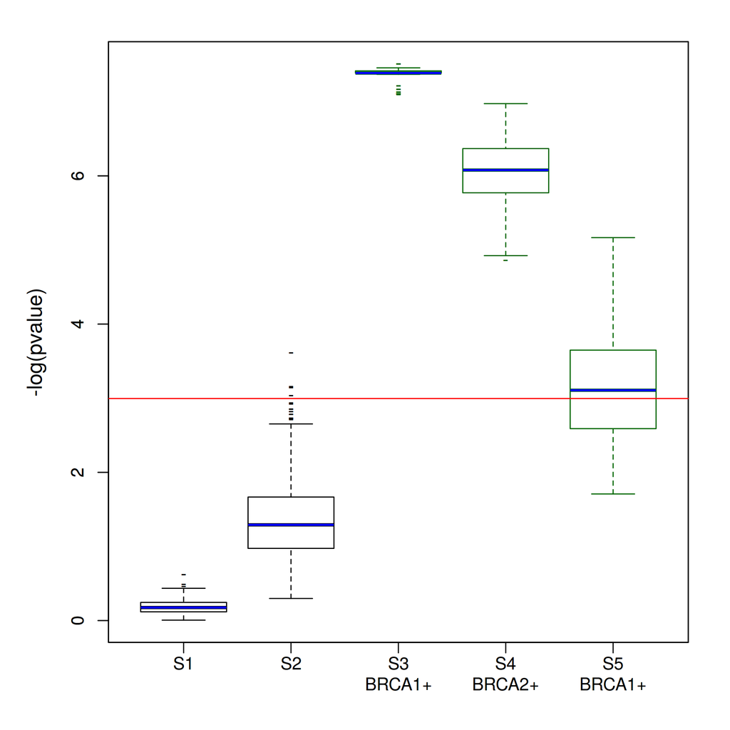

The `Pvquant` vector holds the pvalues quantile of the test for each signature (by default, the 0.5 quantile, i.e. the median). The logarithms of those are considered the Differential Exposure Scores (DES). Signatures with `Pvquant` values below the cutoff, 0.05 by default, are considered as differentially exposed.

```r
# pvalues
diff_exposure$Pvquant
```

```
## [1] 0.8388213093 0.2748421238 0.0006192429 0.0022929362 0.0447092100
```

The `MostExposed` vector contains the name of the group where each differentially exposed signature showed the highest levels of activity.

```r
# most exposed group
diff_exposure$MostExposed
```

```
## [1] NA       NA       "BRCA1+" "BRCA2+" "BRCA1+"
```

### 5.4: Sample Classification

**signeR** can also classify unlabeled samples based on the given labels. In order to do this, those samples must correspond to `NA` values in the labels vector and the Classify function can be used to assign them to one of the defined groups. This example uses the sample labels defined in the DES analysis performed previously.

```r
# note that BRCA_labels [15],[20] and [21] are set to NA
BRCA_labels <- c("wt","BRCA+","BRCA+","BRCA+","BRCA+","BRCA+","BRCA+","wt","wt",
    "wt","wt","BRCA+","wt","BRCA+",NA,"wt","wt","wt","wt",NA,NA)

Class <- Classify(signatures$SignExposures, labels=BRCA_labels)
```

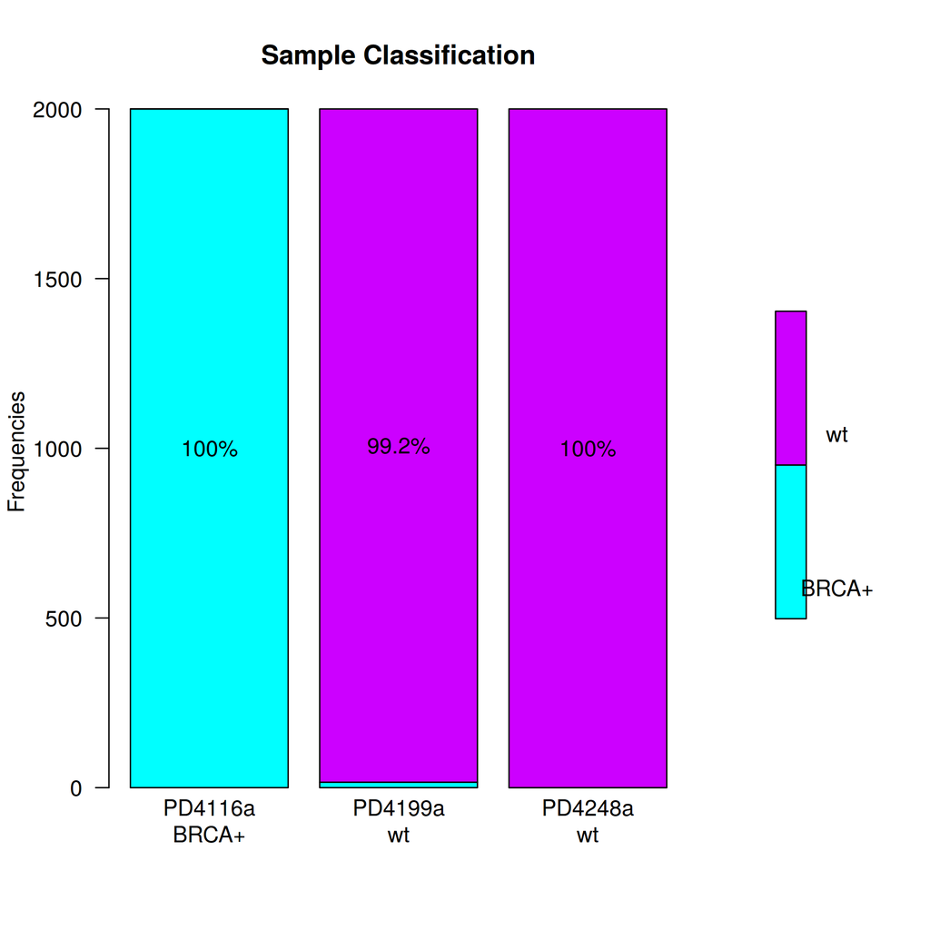

Barplot showing the relative frequencies of assignment of each unlabeled sample to the selected group.

```r
# Final assignments
Class$class
```

```
## [1] "BRCA+" "wt"    "wt"
```

```r
# Relative frequencies of assignment to selected groups
Class$freq
```

```
## PD4116a PD4199a PD4248a
##   1.000   0.992   1.000
```

```r
# All assigment frequencies
Class$allfreqs
```

```
##       PD4116a-BRCA+ PD4199a-wt PD4248a-wt
## BRCA+          2000         16          0
## wt                0       1984       2000
```

## 6: Troubleshooting

### 6.1: Installing on OS X

OS X users might get compilation errors similar to these:

```
ld: warning: directory not found for option '-L/usr/local/lib/x86_64'
ld: library not found for -lgfortran
ld: library not found for -lquadmath
```

This problem arises when the machine is missing gfortran libraries necessary to compile RcppArmadillo and signeR. To install the missing libraries, execute these lines on a terminal:

```
curl -O http://r.research.att.com/libs/gfortran-4.8.2-darwin13.tar.bz2
sudo tar fvxz gfortran-4.8.2-darwin13.tar.bz2 -C /
```

For more information [see this post](http://thecoatlessprofessor.com/programming/rcpp-rcpparmadillo-and-os-x-mavericks-lgfortran-and-lquadmath-error/) and the [Rcpp FAQ, section 2.16](http://dirk.eddelbuettel.com/code/rcpp/Rcpp-FAQ.pdf).

## 7: References

This work has been submitted to Bioinformatics under the title "signeR: An empirical Bayesian approach to mutational signature discovery".

L. B. Alexandrov, S. Nik-Zainal, D. C. Wedge, P. J. Campbell, and M. R. Stratton. Deciphering Signatures of Mutational Processes Operative in Human Cancer. Cell Reports, 3(1):246-259, Jan. 2013. [ [DOI](http://dx.doi.org/10.1016/j.celrep.2012.12.008) ]

A. Fischer, C. J. Illingworth, P. J. Campbell, and V. Mustonen. EMu: probabilistic inference of mutational processes and their localization in the cancer genome. Genome biology, 14(4):R39, Apr. 2013. [ [DOI](http://dx.doi.org/10.1186/gb-2013-14-4-r39) ]